# CS373 HW2

ma438  
Ji Ma  
0028947432

```python
%matplotlib inline
import clustering
import numpy as np
import pandas as pd
import matplotlib.pyplot as plt
import matplotlib.cm as cm
```

## 4 Assignment

### 1. Create a python script that can apply K-means and Agglomerative Clustering algo- rithms in python as specified in the Code Specification section. This is the only piece of code that you need to submit (CODE). We will run several tests on your code to assess it’s correctness. (30 pts)

### 2. K-means analysis You do not need to submit code for this part. Just include the required plots and explanations in the PDF (50 pts).

*(a) Cluster the full Yelp data with values of K = [2, 4, 8, 16, 32, 64] using a random set of examples as the initial centroids. Then, plot the within-cluster sum of squares as a function of K. Which value of k would you choose? Why? (Plot + answer in the PDF)*

```python
sse = []
for k in [2, 4, 8, 16, 32, 64]:
    clustering.main('yelp.csv', k,'km')
    sse.append(globalSse)
```

[output not shown]

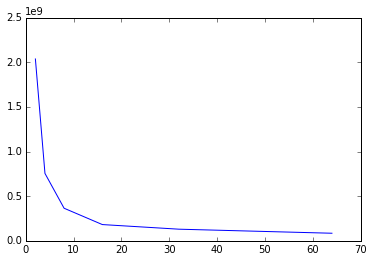

```python
plt.plot([2, 4, 8, 16, 32, 64],[2036552762.63,754859624.826,364738786.417,181817818.865,130087657.174,84653499.3647])
plt.show()
```

*(b) For K = 4 build a scatter 2D plot using the samples (one color per cluster) in two ways: (1) latitude vs. longitude and (2) reviewCount, checkins. What are the dimensions that are driving (most taken into account by) the clustering model? Why?. (2 Plots + answer in the PDF)*

```python
k = 4
clustering.main('yelp.csv', k, 'km')
```

```
WC-SSE=754859624.826
Centroid1=[37.839522,-95.589748,26.446813,72.480362]
Centroid2=[35.543215,-114.483728,1902.928571,6613.000000]
Centroid3=[35.079138,-113.658085,472.111406,2110.612732]
Centroid4=[35.107712,-110.130070,167.429046,640.027801]
```

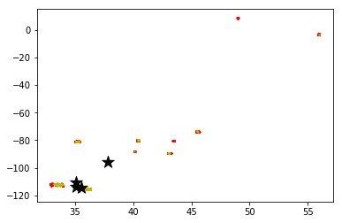

```python
# 1) latitude vs. longitude
colors = ['r', 'g', 'b', 'y', 'c', 'm']
fig, ax = plt.subplots()
for i in range(k):
        points = np.take(clustering.X,clustering.globalCs[i].data, axis=0)
        ax.scatter(points[:, 0] , points[:, 1], s=1, c=colors[i])

C = np.array([c.center for c in clustering.globalCs])
ax.scatter(C[:, 0], C[:, 1], marker='*', s=200, c='#050505')
```

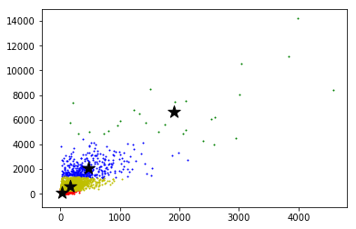

```python
# (2) reviewCount, checkins.
colors = ['r', 'g', 'b', 'y', 'c', 'm']
fig, ax = plt.subplots()
for i in range(k):
        points = np.take(clustering.X,clustering.globalCs[i].data, axis=0)
        ax.scatter(points[:, 2] , points[:, 3], s=1, c=colors[i])

C = np.array([c.center for c in clustering.globalCs])
ax.scatter(C[:, 2], C[:, 3], marker='*', s=200, c='#050505')
```

Clearly, the latitude vs. longitude diagram in the first cluster diagram makes no sense, and the second diagram which reflects the reviewCount, checkins makes a lot of sense. The reviewCount, checkins drives the decision of clustering.

*(c) Do a log transform of reviewCount, checkins, then repeat the above analysis (a) and (b). Discuss any differences in the results. (1 Plot (a) + 2 Plots (b) + answer in the PDF)*

```python
#log transformation
# Repeat a)
sse = []
for k in [2, 4, 8, 16, 32, 64]:
    clustering.logMain('yelp.csv', k,'km')
    sse.append(clustering.globalSse)
```

```
WC-SSE=6791594.2776
Centroid1=[34.547514,-113.278022,3.188372,4.344801]
Centroid2=[42.577464,-70.248593,2.704918,3.261494]
WC-SSE=6709661.24811
Centroid1=[36.080207,-115.140750,4.577675,5.936750]
Centroid2=[36.128767,-115.166017,2.318265,3.445602]
Centroid3=[33.481247,-111.994897,3.091363,4.196716]
Centroid4=[42.577464,-70.248593,2.704918,3.261494]
WC-SSE=408155.367382
Centroid1=[36.131379,-115.160576,1.976346,2.919767]
Centroid2=[36.112626,-115.184977,5.193720,6.493399]
Centroid3=[33.480969,-111.991985,3.102026,4.372092]
Centroid4=[55.411718,-2.296571,2.616600,2.715144]
Centroid5=[36.120352,-115.177173,3.348214,4.786262]
Centroid6=[33.485132,-111.978352,4.601215,5.963565]
Centroid7=[40.751045,-79.918721,2.717486,3.339244]
Centroid8=[33.478623,-112.011332,1.924126,2.648359]
WC-SSE=47427.6931814
Centroid1=[33.471713,-112.010115,1.700496,2.060039]
Centroid2=[35.184493,-80.826863,2.029011,2.885928]
Centroid3=[43.461275,-80.509732,2.151332,2.516115]
Centroid4=[45.508674,-73.585278,3.329921,3.855117]
Centroid5=[33.484520,-112.013449,1.813498,3.793647]
Centroid6=[40.436912,-79.976630,2.918187,3.542586]
Centroid7=[42.479555,-89.164368,2.996785,3.381889]
Centroid8=[55.411718,-2.296571,2.616600,2.715144]
Centroid9=[33.484660,-111.983273,4.174466,5.503089]
Centroid10=[33.481738,-111.995168,3.276718,4.534550]
Centroid11=[33.482326,-111.988363,2.866656,3.127427]
Centroid12=[36.114595,-115.182213,4.532698,5.894910]
Centroid13=[45.510609,-73.603972,1.855937,2.129193]
Centroid14=[36.128765,-115.165796,2.307777,3.428505]
Centroid15=[33.482529,-111.973331,5.279797,6.696655]
Centroid16=[35.187565,-80.830646,3.740421,4.957684]
WC-SSE=38228.2255925
Centroid1=[36.119836,-115.177898,4.005882,4.872759]
Centroid2=[45.509059,-73.593722,2.700123,3.107545]
Centroid3=[33.482135,-111.998310,2.631853,2.360743]
Centroid4=[45.512063,-73.612481,1.477137,1.523604]
Centroid5=[33.484960,-111.977610,4.782556,5.984239]
```

[output cut: 77 more lines]

```
Centroid50=[43.461275,-80.509732,2.151332,2.516115]
Centroid51=[40.432791,-79.983307,1.743286,1.678687]
Centroid52=[33.477280,-111.980941,2.456386,5.413700]
Centroid53=[36.118437,-115.176445,4.046177,4.683275]
Centroid54=[33.476665,-111.989003,3.395173,5.034712]
Centroid55=[36.120767,-115.177268,4.564586,5.485326]
Centroid56=[33.497921,-111.992972,3.879135,4.363287]
Centroid57=[36.110836,-115.181916,5.107757,6.128479]
Centroid58=[40.438701,-79.973855,3.935524,4.667673]
Centroid59=[33.479279,-112.006350,2.835045,4.354121]
Centroid60=[33.470674,-112.023981,1.483741,1.367785]
Centroid61=[36.106091,-115.194521,5.079452,6.881595]
Centroid62=[33.493274,-112.027622,2.144909,2.575321]
Centroid63=[45.508869,-73.586931,3.078028,3.653192]
Centroid64=[36.110075,-115.193435,3.934349,6.434984]
```

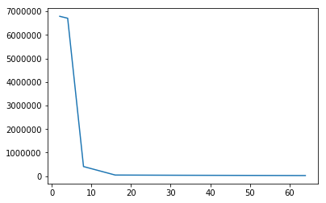

```python
plt.plot([2, 4, 8, 16, 32, 64],sse)
plt.show()
```

After we did the log transformation, it seems like we could get a very good sse at K=16 instead of K=64. This result is very interesting. However, K=64 is still the optimum solution, with a slightly better performance compare to K=16 in SSE based on the enormous scale like the diagramn above.

```python
# repeat b)
k = 4
clustering.logMain('yelp.csv', k, 'km')
```

```
WC-SSE=399727.844921
Centroid1=[43.386060,-79.061272,2.641590,3.096823]
Centroid2=[34.547514,-113.278022,3.188372,4.344801]
Centroid3=[35.678783,-81.569263,2.863581,3.805891]
Centroid4=[55.411718,-2.296571,2.616600,2.715144]
```

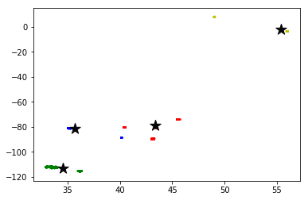

```python
# 1) latitude vs. longitude
colors = ['r', 'g', 'b', 'y', 'c', 'm']
fig, ax = plt.subplots()
for i in range(k):
        points = np.take(clustering.X,clustering.globalCs[i].data, axis=0)
        ax.scatter(points[:, 0] , points[:, 1], s=1, c=colors[i])

C = np.array([c.center for c in clustering.globalCs])
ax.scatter(C[:, 0], C[:, 1], marker='*', s=200, c='#050505')
```

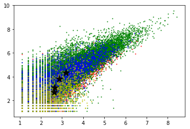

```python
# (2) reviewCount, checkins.
colors = ['r', 'g', 'b', 'y', 'c', 'm']
fig, ax = plt.subplots()
for i in range(k):
        points = np.take(clustering.X,clustering.globalCs[i].data, axis=0)
        ax.scatter(points[:, 2] , points[:, 3], s=1, c=colors[i])

C = np.array([c.center for c in clustering.globalCs])
ax.scatter(C[:, 2], C[:, 3], marker='*', s=200, c='#050505')
```

Now, after the log transformation for reviewCount, checkins, the diagram for reviewCount, checkins is messy as hell. Although the clustering for latitude vs. longitude is kinda sparse, but it is definately drives the clustering decision. So, I would assume that log function would ease certern effect on cluster for applied attributes.

*(d) Repeat the analysis (a) and (b) but first use the function sklearn.preprocessing.scale() command in the original dataset (not the one from (c)) to transform the data so that each attribute has mean = 0 and stdev = 1. Discuss the impact on the empirical results. (1 Plot (a) + 2 Plots (b) + answer in the PDF)*

```python
#log transformation
# Repeat a)
sse = []
for k in [2, 4, 8, 16, 32, 64]:
    clustering.skMain('yelp.csv', k,'km')
    sse.append(clustering.globalSse)
```

```
WC-SSE=66848.6679216
Centroid1=[-0.517416,-0.434531,0.079888,0.114671]
Centroid2=[1.419322,1.191962,-0.219140,-0.314555]
WC-SSE=34780.7192406
Centroid1=[-0.293772,-0.672816,18.561272,15.577383]
Centroid2=[1.447187,1.217946,-0.211552,-0.307014]
Centroid3=[-0.428656,-0.583217,2.706388,3.115837]
Centroid4=[-0.512279,-0.417831,-0.103341,-0.086747]
WC-SSE=20187.9272295
Centroid1=[-0.419921,-0.594796,2.450747,2.891816]
Centroid2=[-0.253987,-0.681881,-0.215234,-0.191484]
Centroid3=[-0.486070,-0.522725,0.749932,0.871910]
Centroid4=[-0.422454,-0.621335,6.034935,6.670917]
Centroid5=[-0.279217,-0.676480,19.991373,16.344588]
Centroid6=[0.232818,0.560336,-0.186605,-0.253399]
Centroid7=[2.025567,1.788992,-0.266879,-0.349936]
Centroid8=[-0.732351,-0.560890,-0.207256,-0.211708]
WC-SSE=7043.65937262
Centroid1=[-0.294761,-0.547048,4.880782,3.352715]
Centroid2=[3.233912,3.624724,-0.253439,-0.352189]
Centroid3=[0.725044,0.509274,-0.238716,-0.312964]
Centroid4=[-0.424096,0.628410,-0.252453,-0.261448]
Centroid5=[-0.421851,-0.639732,7.708453,8.378702]
Centroid6=[-0.418783,0.628224,0.559609,0.547603]
Centroid7=[1.443214,0.904252,-0.290286,-0.356691]
Centroid8=[-0.253577,-0.681812,-0.274194,-0.266271]
Centroid9=[-0.731662,-0.560307,0.228668,0.252993]
Centroid10=[-0.732360,-0.561028,-0.272638,-0.285763]
Centroid11=[-0.437777,-0.587508,2.187218,1.788638]
Centroid12=[-0.255853,-0.682102,22.976140,18.173503]
Centroid13=[-0.480426,-0.624932,1.896226,4.653108]
Centroid14=[-0.504551,-0.612392,0.789461,1.287970]
Centroid15=[-0.255753,-0.682257,0.242359,0.302212]
Centroid16=[0.768380,0.556894,0.750713,0.225504]
WC-SSE=3305.66469303
Centroid1=[-0.470457,-0.618872,1.187523,3.215963]
Centroid2=[0.516750,0.614044,-0.266127,-0.322036]
Centroid3=[-0.546034,-0.607396,1.292361,6.170643]
Centroid4=[-0.424060,0.628471,-0.321773,-0.335127]
Centroid5=[-0.494938,-0.620605,4.261480,11.974298]
```

[output cut: 77 more lines]

```
Centroid50=[-0.424017,0.628427,-0.332539,-0.346716]
Centroid51=[-0.518052,-0.614538,-0.054350,1.277422]
Centroid52=[3.331267,3.590342,-0.335097,-0.380681]
Centroid53=[-0.256212,-0.682039,30.981867,25.905622]
Centroid54=[-0.525724,-0.612541,1.998616,1.689900]
Centroid55=[-0.268767,-0.572201,6.387697,3.396500]
Centroid56=[-0.598562,-0.593559,1.178227,6.932084]
Centroid57=[-0.347320,-0.659048,9.942034,6.522293]
Centroid58=[1.072713,0.640542,-0.324852,-0.375036]
Centroid59=[3.331385,3.590524,0.145500,-0.138201]
Centroid60=[-0.732983,-0.560381,-0.231875,0.181411]
Centroid61=[-0.436247,-0.635878,0.167923,2.125732]
Centroid62=[-0.255008,-0.682345,-0.216442,0.008583]
Centroid63=[1.442997,0.905051,-0.059747,-0.249414]
Centroid64=[-0.733005,-0.561402,-0.359333,-0.363516]
```

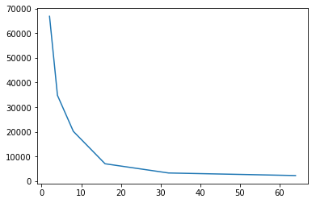

```python
plt.plot([2, 4, 8, 16, 32, 64],sse)
plt.show()
```

The result for the sse is quite similar to the first graph we got, which indicates the optimum SSE will happen when we have k=64. However, the scale for the sse has decreased dramatically.

```python
# repeat b)
k = 4
clustering.skMain('yelp.csv', k, 'km')
```

```
WC-SSE=31585.1892668
Centroid1=[-0.526522,-0.433844,-0.061985,-0.035511]
Centroid2=[1.030001,0.678670,-0.195606,-0.295126]
Centroid3=[-0.406674,-0.599122,4.223576,4.574148]
Centroid4=[3.233912,3.624724,-0.253439,-0.352189]
```

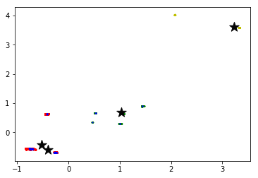

```python
# 1) latitude vs. longitude
colors = ['r', 'g', 'b', 'y', 'c', 'm']
fig, ax = plt.subplots()
for i in range(k):
        points = np.take(clustering.X,clustering.globalCs[i].data, axis=0)
        ax.scatter(points[:, 0] , points[:, 1], s=1, c=colors[i])

C = np.array([c.center for c in clustering.globalCs])
ax.scatter(C[:, 0], C[:, 1], marker='*', s=200, c='#050505')
```

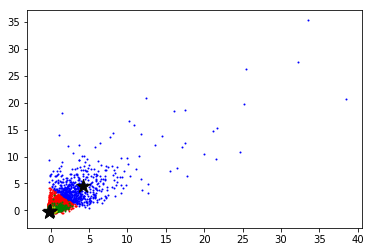

```python
# (2) reviewCount, checkins.
colors = ['r', 'g', 'b', 'y', 'c', 'm']
fig, ax = plt.subplots()
for i in range(k):
        points = np.take(clustering.X,clustering.globalCs[i].data, axis=0)
        ax.scatter(points[:, 2] , points[:, 3], s=1, c=colors[i])

C = np.array([c.center for c in clustering.globalCs])
ax.scatter(C[:, 2], C[:, 3], marker='*', s=200, c='#050505')
```

Surprisingly, the clustering result for latitude vs. longitude and for reviewCount, checkins are both kinda makes sense. However, we can see the result of the clustering is different from the previsou clustering result. The major clustering decision is still the reviewCount, checkins.

### 3. K-means vs. Agglomerative clustering. You do not need to submit code for this part. Just include the required plots and explanations in the PDF (20 pts).

*(a) Run K-means (using a random set of examples as the initial centroids) and Ag- glomerative Clustering on the dummy.csv dataset with k = 3. Make a scatter plot of latitude vs. longitude after each run where each sample is colored according to its cluster color. Subjectively (looking at the plot), which algorithm performs better? Explain. (2 Plots + answer in the PDF)*

```python
# kmeans
k = 3
clustering.main('dummy.csv', k, 'km')
```

```
WC-SSE=4064.41023576
Centroid1=[-2.580575,0.764385,0.000000,0.000000]
Centroid2=[-3.245872,2.908842,0.000000,0.000000]
Centroid3=[1.024805,-0.879128,0.000000,0.000000]
```

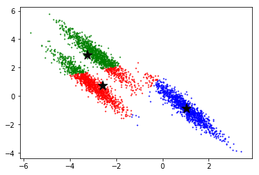

```python
# kmeans: latitude vs. longitude
colors = ['r', 'g', 'b', 'y', 'c', 'm']
fig, ax = plt.subplots()
for i in range(k):
        points = np.take(clustering.X,clustering.globalCs[i].data, axis=0)
        ax.scatter(points[:, 0] , points[:, 1], s=1, c=colors[i])

C = np.array([c.center for c in clustering.globalCs])
ax.scatter(C[:, 0], C[:, 1], marker='*', s=200, c='#050505')
```

```python
# Agglomerative clustering
k = 3
clustering.main('dummy.csv', k, 'ac')
```

[output not shown]

[output cut: 6944 more lines]

[output not shown]

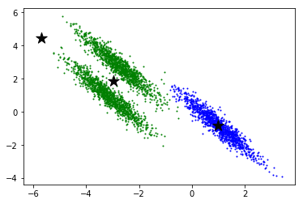

```python
# Agglomerative clustering: latitude vs. longitude
colors = ['r', 'g', 'b', 'y', 'c', 'm']
fig, ax = plt.subplots()
for i in range(k):
        points = np.take(clustering.X,clustering.globalCs[i].data, axis=0)
        ax.scatter(points[:, 0] , points[:, 1], s=1, c=colors[i])

C = np.array([c.center for c in clustering.globalCs])
ax.scatter(C[:, 0], C[:, 1], marker='*', s=200, c='#050505')
```

Well, this is not what I expected from my algorithm, so I compared my implementation of AC with sklearn AC algorithm to make sure I am correct.

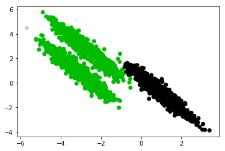

```python
from sklearn.cluster import AgglomerativeClustering
data = pd.read_csv('dummy.csv', sep=',', quotechar='"', header=0)
data = data[['latitude', 'longitude', 'reviewCount', 'checkins']]
ac = AgglomerativeClustering(n_clusters=3,linkage="average")
ac.fit(data)
plt.scatter(data.as_matrix()[:, 0], data.as_matrix()[:, 1], c=ac.labels_, cmap=plt.cm.spectral)
plt.show()
```

OK, so my implementation is indeed correct... The Agglomerative clustering generated a more smooth and 'reasonable' cluserting pattern in terms of smoothness, although it only technically gives two clusters vissualy, compare to the 'hard cut' by kmeans. So, if there is a way to combine both of the algorithm, I would say Agglomerative clustering performs better, but it takes long time to train.

*(b) Does K-means always yield the same result if it is applied over and over? What about Agglomerative Clustering?*

K-Means: it won't have same result. Because of the randomized initial k centers, it will grow the clusters depends on the randomized centers, which will lead to different result.

Agglomerative Clustering: The result will be the same. Since, the basic idea is just to group the cluster with the most 'similarity' together, so there's no randomness in the progress, which make the result consistant.

*(c) If K-means and Agglomerative clustering are applied on the Yelp dataset, which one is going to take more time? Why? (answer in the PDF)*

K-Means: The complexity is O(n*k*i) (n = total elements, k = number of cluster i = iteration)

Agglomerative Clustering: The complexity is O(n^3) and takes O(n^2) memory, which makes it too slow for even medium data sets.

n*k*i generally will be smaller than n^3

Our yelp data set is humangous, so kmeans is definietly a better solution under the assumtption of we will have less clusters and relative short amount of iteration.